# AreWeRepresented Census and NCACC Categorical Data

D. Hopp

April 25, 2018

INPUT:  
AWR_Census_NCACC.RData  
df_nc_voted.RData

The AWR_Census_NCACC.RData image includes the directory paths data_dir and output_dir

OUTPUT:  
df_merge_county_sex_race_20161108.csv.gz  
df_cc_est2016_compare.csv.gz  
df_cc_est2016_compare_Hisp.csv.gz df_merge_county_sex_race_OMU_20161108.csv.gz - this is a view, see v_df_merge_county_sex_race_OMU_20161108()  
AWR_Census_NCACC_cat.RData an amalgamation of AWR_Census_NCACC.RData and objects created in this script

## Who is Using Which Codes for What

```r
load("AWR_Census_NCACC.RData")
load("df_nc_voted.RData")
```

## NCSBE

### Registration Data Race and Ethnicity

results_pct_20161108.txt via  
https://dl.ncsbe.gov/index.html?prefix=ENRS/2016_11_08/

Defined as:  
dfcl_regis_party_cd <- df_regis_stats_20161108 %>% dplyr::distinct(party_cd) dfcl_regis_race_code <- df_regis_stats_20161108 %>% dplyr::distinct(race_code)  
dfcl_regis_ethnic_code <- df_regis_stats_20161108 %>% dplyr::distinct(ethnic_code)  
dfcl_regis_sex_code <- df_regis_stats_20161108 %>% dplyr::distinct(sex_code)

```r
dfcl_regis_party_cd
```

```
##   party_cd
## 1      DEM
## 2      UNA
## 3      LIB
## 4      REP
```

```r
dfcl_regis_race_code
```

```
##   race_code
## 1         W
## 2         B
## 3         O
## 4         U
## 5         I
## 6         A
## 7         M
```

```r
dfcl_regis_ethnic_code
```

```
##   ethnic_code
## 1          NL
## 2          UN
## 3          HL
```

```r
dfcl_regis_sex_code
```

```
##   sex_code
## 1        F
## 2        M
## 3        U
```

Convenience data frame:  
Race (only) by county in wide format:

```r
fn_df_regis_stats_20161108_county_race_wide <- function() {
  df_ <-
  df_regis_stats_20161108 %>%
  dplyr::select(
    total_voters,
    race_code,
    FIPS3
  ) %>%
  reshape2::dcast(
    FIPS3~race_code,
    value.var = "total_voters",
    sum
  )
  #
  return(df_)
}
```

Convenience data frame:  
Race (only) by county in long format:

```r
fn_df_regis_stats_20161108_county_race_long <- function(){
  df_ <-
  df_regis_stats_20161108 %>%
  dplyr::select(
    total_voters,
    race_code,
    FIPS3
  ) %>%
  dplyr::group_by(
    FIPS3,
    race_code
  ) %>%
  dplyr::summarize(
    N=sum(total_voters)
  ) %>%
  dplyr::ungroup()
  #
  return(df_)
}
```

```r
str(fn_df_regis_stats_20161108_county_race_long())
```

```
## Classes 'tbl_df', 'tbl' and 'data.frame':    699 obs. of  3 variables:
##  $ FIPS3    : chr  "001" "001" "001" "001" ...
##  $ race_code: chr  "A" "B" "I" "M" ...
##  $ N        : int  652 20719 274 768 2026 4305 72496 133 1007 33 ...
```

Race and sex by county:

```r
fn_df_regis_stats_20161108_county_sex_race <- function(){
  df_ <-
  df_regis_stats_20161108 %>%
  dplyr::select(
    total_voters,
    sex_code,
    race_code,
    FIPS3
  ) %>%
  dplyr::group_by(
    FIPS3,
    sex_code,
    race_code
  ) %>%
  dplyr::summarise(
    N=sum(total_voters)
  ) %>%
  dplyr::ungroup()
  #
  return(df_)
}
```

```r
str(fn_df_regis_stats_20161108_county_sex_race())
```

```
## Classes 'tbl_df', 'tbl' and 'data.frame':    1972 obs. of  4 variables:
##  $ FIPS3    : chr  "001" "001" "001" "001" ...
##  $ sex_code : chr  "F" "F" "F" "F" ...
##  $ race_code: chr  "A" "B" "I" "M" ...
##  $ N        : int  356 12017 154 433 1005 1224 39325 278 8564 114 ...
```

## Census Bureau

### Race and Ethnicity

cc-est2016-alldata-37.csv via  
https://www.census.gov/data/tables/2016/demo/popest/counties-detail.html  
“Annual County Resident Population Estimates by Age, Sex, Race, and Hispanic Origin: April 1, 2010 to July 1, 2016”

Census 2010 Race Methodology: [here](https://www2.census.gov/programs-surveys/popest/technical-documentation/methodology/modified-race-summary-file-method/mrsf2010.pdf) and [here](https://www.census.gov/prod/cen2010/briefs/c2010br-02.pdf)

Gender is for each Race, and also total, e.g.,  
TOT_MALE, TOT_FEMALE, WA_MALE, WA_FEMALE etc.

WA White alone  
BA Black or African American alone  
IA American Indian and Alaska Native alone  
AA Asian alone  
NA Native Hawaiian and Other Pacific Islander alone  
TOM Two or More Races

Hispanic is double-counted but included as additional columns:  
H Hispanic

These are double-counted and are not included:  
WAC White alone or in combination  
BAC Black or African American alone  
IAC American Indian and Alaska Native alone or in combination

Counts by total population (all) and by voting age (18 and older)  
Breakdown by race, ignoring ethnicity.  
This is for entire state:

```r
fn_df_cc_est2016_tot_subset() %>%
dplyr::select(TOT_POP,nWA,nBA,nIA,nAA,nTOM,pop) %>%
reshape2::melt(
  id.vars="pop"
) %>%
reshape2::dcast(
  pop~variable,
  value.var = "value",
  sum
)
```

```
##       pop TOT_POP     nWA     nBA    nIA    nAA   nTOM
## 1     all 9841590 7047899 2175191 153399 255416 198088
## 2 voteage 7546959 5539560 1608467 108052 188136  95270
```

This is by county (by FIPS3): df_cc_est2016_county_race_dcast

```r
str(df_cc_est2016_county_race_dcast)
```

```
## 'data.frame':    200 obs. of  8 variables:
##  $ pop    : chr  "all" "all" "all" "all" ...
##  $ FIPS3  : chr  "001" "003" "005" "007" ...
##  $ TOT_POP: num  154622 36999 10896 25959 27036 ...
##  $ nWA    : num  117216 33829 10473 12481 26308 ...
##  $ nBA    : num  29965 2123 171 12625 234 ...
##  $ nIA    : num  2134 164 51 203 84 ...
##  $ nAA    : num  2224 386 74 306 131 ...
##  $ nTOM   : num  2965 484 122 324 268 ...
```

## Reasonable Mappings

Gender:  
NCSBE sex_code: M, F, U Census Gender is for each Race, and also total, e.g., TOT_MALE, TOT_FEMALE, WA_MALE, WA_FEMALE etc.

Race: NCSBE race_code: A, B, I, M, O, U, W (does not include Native Hawaiian explicitly)  
Census Race (see Gender): WA, BA, IA (American Indian), AA, NA (Native Hawaiian etc.), TOM (two or more)

### Remapping

Convince census to look like NCSBE data:

```r
fn_df_cc_est2016_county_sex_race_long_recoded <- function(){
  #
  #lst_colHead_code <- list(
  #  "WA_"="W","BA_"="B","IA_"="I","AA_"="A","TOM_"="M"
  #)
  #lst_colHead_code_names <- names(lst_colHead_code)
  recode_colHead <- "'WA_MALE'='W'; 'BA_MALE'='B'; 'IA_MALE'='I'; 'AA_MALE'='A'; 'TOM_MALE'='M'; 'WA_FEMALE'='W'; 'BA_FEMALE'='B'; 'IA_FEMALE'='I'; 'AA_FEMALE'='A'; 'TOM_FEMALE'='M'; else='O'"
  #
  df_ <-
  df_cc_est2016_tot %>%
  dplyr::select(
    FIPS3,
    WA_MALE,
    WA_FEMALE,
    BA_MALE,
    BA_FEMALE,
    IA_MALE,
    IA_FEMALE,
    AA_MALE,
    AA_FEMALE,
    NA_MALE,
    NA_FEMALE,
    TOM_MALE,
    TOM_FEMALE,
    pop
  ) %>%
  reshape2::melt(
    id.vars=c("pop","FIPS3")
  ) %>%
  dplyr::mutate(
    variable=as.character(variable)
  ) %>%
  dplyr::mutate(
    sex=
      ifelse(
        stringr::str_detect(variable,"FEMALE"),"F","M"
      ),
    race=
      car::recode(variable,recode_colHead)
  ) %>%
  dplyr::select(
    pop,
    FIPS3,
    sex,
    race,
    value
  ) %>%
  dplyr::rename(
    N=value
  ) %>%
  dplyr::arrange(
    pop,
    FIPS3,
    sex,
    race
  )
  #
  return(df_)
}
```

```r
str(fn_df_cc_est2016_county_sex_race_long_recoded())
```

```
## 'data.frame':    2400 obs. of  5 variables:
##  $ pop  : chr  "all" "all" "all" "all" ...
##  $ FIPS3: chr  "001" "001" "001" "001" ...
##  $ sex  : chr  "F" "F" "F" "F" ...
##  $ race : chr  "A" "B" "I" "M" ...
##  $ N    : num  1202 16157 1087 1503 54 ...
```

```r
df_cc_est2016_county_sex_race_long_recoded <- fn_df_cc_est2016_county_sex_race_long_recoded()
```

## NCACC

Notice that categories do NOT provide sex vs. race, just totals.  
In that sense, NCACC data is not compatible with census or NCSBE.  
Keep in mind that race most likely is self-reported.

```r
fn_df_NCACC_2016_demog_subset <- function(){
  df_ <-
  df_NCACC_2016_demog %>%
  dplyr::mutate(
    nmale=ncomm-nfemale,
    nother_race=ncomm-(nwhite+nafam+namin)
  ) %>%
  dplyr::select(
    FIPS3,
    nmale,
    nfemale,
    nwhite,
    nafam,
    namin,
    nother_race
  )
  #
  return(df_)
}
```

```r
str(fn_df_NCACC_2016_demog_subset())
```

```
## 'data.frame':    100 obs. of  7 variables:
##  $ FIPS3      : chr  "001" "003" "005" "007" ...
##  $ nmale      : num  4 5 5 5 4 3 7 3 7 4 ...
##  $ nfemale    : num  1 0 0 2 1 2 0 2 2 1 ...
##  $ nwhite     : num  5 5 5 3 5 5 5 3 6 5 ...
##  $ nafam      : num  0 0 0 4 0 0 2 2 3 0 ...
##  $ namin      : num  0 0 0 0 0 0 0 0 0 0 ...
##  $ nother_race: num  0 0 0 0 0 0 0 0 0 0 ...
```

## NCSBE Voting Data

```r
df_nc_voted_subset_long <-
df_nc_voted %>%
dplyr::filter(
  status_cd=="A"
) %>%
dplyr::inner_join(
  df_FIPS %>%
    dplyr::select(
      county_id,
      FIPS3
    ),
  by="county_id"
) %>%
dplyr::select(
  FIPS3,
  gender_code,
  race_code
) %>%
reshape2::dcast(
  FIPS3+gender_code+race_code~.
) %>%
plyr::rename(
  c(
    "."="N",
    "race_code"="race",
    "gender_code"="sex"
  )
) %>%
na.omit() %>%
dplyr::arrange(
  FIPS3,
  sex,
  race
)
str(df_nc_voted_subset_long)
```

```
## 'data.frame':    1908 obs. of  4 variables:
##  $ FIPS3: chr  "001" "001" "001" "001" ...
##  $ sex  : chr  "F" "F" "F" "F" ...
##  $ race : chr  "A" "B" "I" "M" ...
##  $ N    : int  241 8461 106 232 615 746 27821 164 5013 69 ...
##  - attr(*, "na.action")=Class 'omit'  Named int [1:13] 162 163 458 459 460 704 798 799 821 912 ...
##   .. ..- attr(*, "names")= chr [1:13] "162" "163" "458" "459" ...
```

## Bring Together

Create one data frame to hold all of above (long shape)  
* Columns:  
* pop: + all: Census Bureau all population  
+ voteage: Census Bureau 18 years and older  
+ regis: NCSBE registered to vote  
+ voted: NCSBE voted  
* sex:  
+ F: Female  
+ M: Male  
+ U: Unknown  
* race:  
A: Asian  
B: African-American  
I: American Indian  
M: More than one  
O: Other  
U: Unknown  
W: White

```r
df_merge_county_sex_race_20161108 <-
  rbind(
    fn_df_regis_stats_20161108_county_sex_race() %>%
    dplyr::rename(
      sex=sex_code,
      race=race_code
    ) %>%
    dplyr::mutate(
      pop="regis"
    ) %>%
    dplyr::select(
      pop,
      FIPS3,
      sex,
      race,
      N
    ),
    df_cc_est2016_county_sex_race_long_recoded %>%
      dplyr::filter(
        race != "all"
      ),
    df_nc_voted_subset_long %>%
    dplyr::mutate(
      pop="voted"
    ) %>%
    dplyr::select(
      pop,
      FIPS3,
      sex,
      race,
      N
    )
  )
```

```r
str(df_merge_county_sex_race_20161108)
```

```
## Classes 'tbl_df', 'tbl' and 'data.frame':    6280 obs. of  5 variables:
##  $ pop  : chr  "regis" "regis" "regis" "regis" ...
##  $ FIPS3: chr  "001" "001" "001" "001" ...
##  $ sex  : chr  "F" "F" "F" "F" ...
##  $ race : chr  "A" "B" "I" "M" ...
##  $ N    : num  356 12017 154 433 1005 ...
```

Write df_merge_county_sex_race_20161108 as a csv file.

```r
readr::write_csv(
  df_merge_county_sex_race_20161108,
  paste0(output_dir,"df_merge_county_sex_race_20161108.csv.gz")
)
```

Any analysis has to be aware of the numbers by race, which present comparison challenges across the sources.  
The “O” and “U” categories are of particular note.

O (Other) and U (Unknown) are used in the NCSBE data, as per ncvhis_ncvoter_data_format.txt but only O in the Census data.  
Are both O designations to be considered comparable?

Display counts by race:

```r
fn_merge_county_sex_race_20161108_dcast <- function(){
  # all this to get a nice lookin dcast
  # there must be a better way
  # use an ordered factor
  #
  df_ <- df_merge_county_sex_race_20161108
  df_$pop <- as.factor(df_$pop)
  df_$pop <- ordered(
    df_$pop,
    levels=c("all","voteage","regis","voted")
  )
  #
  df_dcast <-
  df_ %>%
  dplyr::select(
    pop,
    race,
    N
  ) %>%
  reshape2::dcast(
    race~pop,
    value.var="N",
    sum,
    margins="race"
  )
  #
  return(
    df_dcast
  )
}
```

```r
fn_merge_county_sex_race_20161108_dcast()
```

```
##    race     all voteage   regis   voted
## 1     A  255416  188136   81210   49653
## 2     B 2175191 1608467 1536677  940914
## 3     I  153399  108052   56661   27836
## 4     M  198088   95270   47560   24756
## 5     O   11597    7461  166529   87990
## 6     U       0       0  233220  138317
## 7     W 7047899 5539560 4802439 3307070
## 8 (all) 9841590 7546946 6924296 4576536
```

### This combines the df_merge_county_sex_race_20161108 race categories M, O, and U into O alone.

```r
v_df_merge_county_sex_race_OMU_20161108 <- function(){
  df_ <-
  df_merge_county_sex_race_20161108 %>%
    dplyr::mutate(
      race=ifelse(race %in% c("M","U"),"O",race)
    ) %>%
  reshape2::dcast(
    pop+FIPS3+sex+race~.,
    value.var="N",
    sum
  ) %>%
  plyr::rename(
    c("."="N")
  )
  #
  return(df_)
}
```

```r
str(v_df_merge_county_sex_race_OMU_20161108())
```

```
## 'data.frame':    4803 obs. of  5 variables:
##  $ pop  : chr  "all" "all" "all" "all" ...
##  $ FIPS3: chr  "001" "001" "001" "001" ...
##  $ sex  : chr  "F" "F" "F" "F" ...
##  $ race : chr  "A" "B" "I" "O" ...
##  $ N    : num  1202 16157 1087 1557 60992 ...
```

Check on counts:

```r
df_merge_county_sex_race_20161108 %>%
  dplyr::filter(
    race %in% c("O","M","U")
  ) %>%
  reshape2::dcast(
    pop+race~.,
    value.var="N",
    sum
  )
```

```
##        pop race      .
## 1      all    M 198088
## 2      all    O  11597
## 3    regis    M  47560
## 4    regis    O 166529
## 5    regis    U 233220
## 6  voteage    M  95270
## 7  voteage    O   7461
## 8    voted    M  24756
## 9    voted    O  87990
## 10   voted    U 138317
```

```r
v_df_merge_county_sex_race_OMU_20161108() %>%
  dplyr::filter(
    race == "O"
  ) %>%
  reshape2::dcast(
    pop+race~.,
    value.var="N",
    sum
  )
```

```
##       pop race      .
## 1     all    O 209685
## 2   regis    O 447309
## 3 voteage    O 102731
## 4   voted    O 251063
```

```r
readr::write_csv(
  v_df_merge_county_sex_race_OMU_20161108(),
  paste0(output_dir,"df_merge_county_sex_race_OMU_20161108.csv.gz")
)
```

## How do the Census Bureau race classification sets compare?

### Discussion

These are the column headings in cc-est2016-alldata-37.csv as described in cc-est2016-alldata.pdf

SUMLEV,STATE,COUNTY,STNAME,CTYNAME,YEAR,AGEGRP,  
TOT_POP,TOT_MALE,TOT_FEMALE,  
WA_MALE,WA_FEMALE,BA_MALE,BA_FEMALE,IA_MALE,IA_FEMALE,AA_MALE,AA_FEMALE,NA_MALE,NA_FEMALE,TOM_MALE,TOM_FEMALE,  
WAC_MALE,WAC_FEMALE,BAC_MALE,BAC_FEMALE,IAC_MALE,IAC_FEMALE,AAC_MALE,AAC_FEMALE,NAC_MALE,NAC_FEMALE,  
NH_MALE,NH_FEMALE,NHWA_MALE,NHWA_FEMALE,NHBA_MALE,NHBA_FEMALE,NHIA_MALE,NHIA_FEMALE,NHAA_MALE,NHAA_FEMALE, NHNA_MALE,NHNA_FEMALE,NHTOM_MALE,NHTOM_FEMALE, NHWAC_MALE,NHWAC_FEMALE,NHBAC_MALE,NHBAC_FEMALE,NHIAC_MALE,NHIAC_FEMALE,NHAAC_MALE,NHAAC_FEMALE,NHNAC_MALE,NHNAC_FEMALE, H_MALE,H_FEMALE,HWA_MALE,HWA_FEMALE,HBA_MALE,HBA_FEMALE,HIA_MALE,HIA_FEMALE,HAA_MALE,HAA_FEMALE,HNA_MALE, HNA_FEMALE,HTOM_MALE,HTOM_FEMALE, HWAC_MALE,HWAC_FEMALE,HBAC_MALE,HBAC_FEMALE,HIAC_MALE,HIAC_FEMALE,HAAC_MALE,HAAC_FEMALE,HNAC_MALE,HNAC_FEMALE

Question: Are there any significant differences in counts when looking at the “WA_MALE…” and the “WAC_MALE…” categorizations? For now, we will ignore the Hispanic categorizations (NH_MALE…). Notice that there is no Unknown category. We will refer to the WA_… as Source A, and the WAC_… as Source B.

The following is from https://www2.census.gov/programs-surveys/popest/technical-documentation/methodology/2010-2016/2016-natstcopr-meth.pdf

“we modify the 2010 Census race categories to be consistent with the race categories that appear in our input data. The 2010 Census allowed for responses that included one or more of the race groups defined by the Office of Management and Budget (OMB) in 1997: White; Black or African American; American Indian and Alaska Native; Asian; and Native Hawaiian and Other Pacific Islander. The 2010 Census also allowed responses that included “Some other race.” The Population Estimates program produces estimates in five race categories and their combinations.”Some other race" responses have been “modified” to be consistent with these race categories.

This modification process recategorizes responses that include “Some other race” alone or in combination with other races into one or more of the five OMB race categories. When a “Some other race” response appears in combination with one or more of the OMB races, we remove the “Some other race” category. Responses that include “Some other race” alone are allocated to one or more of the five OMB categories listed above using information on the household when available or a hot decking procedure if necessary.

Note that this editing process produces tabulations for our estimates that show fewer people reporting two or more races than similar tabulations from the 2010 Census. This is primarily because responses of “Some other race” and one of the OMB defined races in the 2010 Census appear in the single OMB race category in the estimates base."

### Conclusion

This conclusion is substantiated in the script that follows below. It is presented here for clarity.

The problem with these talleys seems to be that the “HWA_…” (including HTOM_) sum equals H_MALE+H_FEMALE,  
while the “HWAC_…” series sum is larger. Whatever the source of this, for our purposes the Hispanic counts  
will be represented by the “HWA_…” series.

### Create R Objects

Utility data frame

```r
df_cc_est2016_tot_only <-
  df_cc_est2016_tot %>%
  dplyr::select(
    pop,
    FIPS3,
    TOT_POP,
    TOT_MALE,
    TOT_FEMALE
  )
```

```r
str(df_cc_est2016_tot_only)
```

```
## 'data.frame':    200 obs. of  5 variables:
##  $ pop       : chr  "all" "all" "all" "all" ...
##  $ FIPS3     : chr  "001" "003" "005" "007" ...
##  $ TOT_POP   : num  154622 36999 10896 25959 27036 ...
##  $ TOT_MALE  : num  73627 18827 5397 13441 13339 ...
##  $ TOT_FEMALE: num  80995 18172 5499 12518 13697 ...
```

Function to create a data frame used in comparison of the two categorizations as per above.

```r
fn_df_cc_est2016_compare <- function(){
  #
  # Use vectors to parse column headings.
  #
  # 4 categories + Other (which includes TOM_)
  #
  #colHead_A_code <- c("WA_","BA_","IA_","AA_")
  #colHead_A_abbrev <- c("W","B","I","A")
  #lst_colHead_A_code <- list(
  #  "WA_"="W","BA_"="B","IA_"="I","AA_"="A"
  #)
  #lst_colHead_A_code_names <- names(lst_colHead_A_code)
  recode_colHead_A <-
    "'WA_MALE'='W'; 'BA_MALE'='B'; 'IA_MALE'='I'; 'AA_MALE'='A'; 'WA_FEMALE'='W'; 'BA_FEMALE'='B'; 'IA_FEMALE'='I'; 'AA_FEMALE'='A'; else='O'"
  #
  df_ <-
  df_cc_est2016_tot %>%
  dplyr::select(
    FIPS3,
    WA_MALE,
    WA_FEMALE,
    BA_MALE,
    BA_FEMALE,
    IA_MALE,
    IA_FEMALE,
    AA_MALE,
    AA_FEMALE,
    NA_MALE,
    NA_FEMALE,
    TOM_MALE,
    TOM_FEMALE,
    pop
    ) %>%
  reshape2::melt(
    id.vars=c("pop","FIPS3")
  ) %>%
  dplyr::mutate(
    variable=as.character(variable)
  ) %>%
  dplyr::rowwise() %>%
  dplyr::mutate(
    sex=
      ifelse(
        stringr::str_detect(variable,"FEMALE"),
        "F",
        "M"
      ),
  race=
    car::recode(variable,recode_colHead_A),
  source="A"
  ) %>%
  data.frame() %>%
  dplyr::select(
    pop,
    source,
    FIPS3,
    sex,
    race,
    value
  )
  #
  # 4 categories + Other
  #
  #lst_colHead_B_code <- list(
  #  "WAC_"="W","BAC_"="B","IAC_"="I","AAC_"="A"
  #)
  #lst_colHead_B_code_names <- names(lst_colHead_B_code)
  recode_colHead_B <-
    "'WAC_MALE'='W'; 'BAC_MALE'='B'; 'IAC_MALE'='I'; 'AAC_MALE'='A'; 'WAC_FEMALE'='W'; 'BAC_FEMALE'='B'; 'IAC_FEMALE'='I'; 'AAC_FEMALE'='A'; else='O'"
  #
  df_B <-
  df_cc_est2016_tot %>%
  dplyr::select(
    FIPS3,
    WAC_MALE,
    WAC_FEMALE,
    BAC_MALE,
    BAC_FEMALE,
    IAC_MALE,
    IAC_FEMALE,
    AAC_MALE,
    AAC_FEMALE,
    NAC_MALE,
    NAC_FEMALE,
    pop
    ) %>%
  reshape2::melt(
    id.vars=c("pop","FIPS3")
  ) %>%
  dplyr::mutate(
    variable=as.character(variable)
  ) %>%
  dplyr::rowwise() %>%
  dplyr::mutate(
    sex=
      ifelse(
        stringr::str_detect(variable,"FEMALE"),
        "F",
        "M"
      ),
  race=
    car::recode(variable,recode_colHead_B),
    source="B"
  ) %>%
  data.frame() %>%
  dplyr::select(
    pop,
    source,
    FIPS3,
    sex,
    race,
    value
  )
  #
  # summarize
  #
  df_ <-
  rbind(
    df_,
    df_B
  ) %>%
  dplyr::group_by(
    pop,
    source,
    FIPS3,
    sex,
    race
  ) %>%
  dplyr::summarize(
    N=sum(value)
  ) %>%
  dplyr::ungroup()
  #
  return(df_)
}
```

```r
df_cc_est2016_compare <- fn_df_cc_est2016_compare()
str(df_cc_est2016_compare)
```

```
## Classes 'tbl_df', 'tbl' and 'data.frame':    4000 obs. of  6 variables:
##  $ pop   : chr  "all" "all" "all" "all" ...
##  $ source: chr  "A" "A" "A" "A" ...
##  $ FIPS3 : chr  "001" "001" "001" "001" ...
##  $ sex   : chr  "F" "F" "F" "F" ...
##  $ race  : chr  "A" "B" "I" "O" ...
##  $ N     : num  1202 16157 1087 1557 60992 ...
```

Write as a csv file

```r
readr::write_csv(
  df_cc_est2016_compare,
  paste0(output_dir,"df_cc_est2016_compare.csv.gz")
)
```

View to sum male and female

```r
v_df_cc_est2016_compare <- function(){
  fn_df_cc_est2016_compare() %>%
  dplyr::group_by(
    pop,
    source,
    FIPS3,
    race
  ) %>%
  dplyr::summarize(
    N_F_M=sum(N)
  ) %>%
  dplyr::ungroup()
}
```

```r
str(v_df_cc_est2016_compare())
```

```
## Classes 'tbl_df', 'tbl' and 'data.frame':    2000 obs. of  5 variables:
##  $ pop   : chr  "all" "all" "all" "all" ...
##  $ source: chr  "A" "A" "A" "A" ...
##  $ FIPS3 : chr  "001" "001" "001" "001" ...
##  $ race  : chr  "A" "B" "I" "O" ...
##  $ N_F_M : num  2224 29965 2134 3083 117216 ...
```

### Compare source A vs B to try to see what race count differences might be.

```r
# drop sex
df_cc_est2016_compare_N <- v_df_cc_est2016_compare()
#
df_cc_est2016_compare_N_source <-
dplyr::inner_join(
  df_cc_est2016_compare_N %>%
    dplyr::filter(
      source=="A" &
      pop=="all"
    ),
  df_cc_est2016_compare_N %>%
    dplyr::filter(
      source=="B" &
      pop=="all"
    ),
  by=c("pop","FIPS3","race")
) %>%
dplyr::select(
  pop,
  FIPS3,
  race,
  N_F_M.x,
  N_F_M.y
) %>%
dplyr::rename(
  N.A=N_F_M.x,
  N.B=N_F_M.y
) %>%
dplyr::mutate(
  pctN.A=round(N.A/(N.A+N.B),digits=3),
  logitN.A=round(log((N.A/(N.A+N.B))/(1-(N.A/(N.A+N.B)))),digits=3)
)
```

```r
str(df_cc_est2016_compare_N_source)
```

```
## Classes 'tbl_df', 'tbl' and 'data.frame':    500 obs. of  7 variables:
##  $ pop     : chr  "all" "all" "all" "all" ...
##  $ FIPS3   : chr  "001" "001" "001" "001" ...
##  $ race    : chr  "A" "B" "I" "O" ...
##  $ N.A     : num  2224 29965 2134 3083 117216 ...
##  $ N.B     : num  2801 31877 3127 263 119813 ...
##  $ pctN.A  : num  0.443 0.485 0.406 0.921 0.495 0.464 0.467 0.34 0.947 0.497 ...
##  $ logitN.A: num  -0.231 -0.062 -0.382 2.462 -0.022 ...
```

### Quintiles

```r
fn_df_cc_est2016_compare_N_quintile <- function(race_){
  ret <- list()
  df_ <-
  df_cc_est2016_compare_N_source %>%
    dplyr::filter(
      race==race_
    )
  ret[[1]] <- median(df_[["logitN.A"]])
  ret[[2]] <- quantile(df_[["logitN.A"]],probs=seq(0,1,.2))
  #
  return(ret)
}
#
B_df_cc_est2016_compare_N_quintile <- fn_df_cc_est2016_compare_N_quintile("B")
W_df_cc_est2016_compare_N_quintile <- fn_df_cc_est2016_compare_N_quintile("W")
```

The Black median is -0.063 and the White median is -0.019.

The quintiles for Blacks are

```r
B_df_cc_est2016_compare_N_quintile[[2]]
```

```
##      0%     20%     40%     60%     80%    100%
## -1.2470 -0.1542 -0.0734 -0.0470 -0.0278 -0.0100
```

and for Whites are

```r
W_df_cc_est2016_compare_N_quintile[[2]]
```

```
##      0%     20%     40%     60%     80%    100%
## -0.0640 -0.0260 -0.0210 -0.0180 -0.0148 -0.0080
```

### Cleveland Plots

Here are Cleveland plots for the logit of Source A (WA_…) proportion. A logit of 0 means that N.A=N.B, since the total is N.A+N.B. Negative values mean that N.A<N.B. Logit used, rather than percentage, since there is a great range in total count over the counties. Reporting percentages would be associated with larger erros for the smaller counties.

The two plots show a remarkable difference in scale, the difference between N.A and N.B being much larger for Black than for White.

White

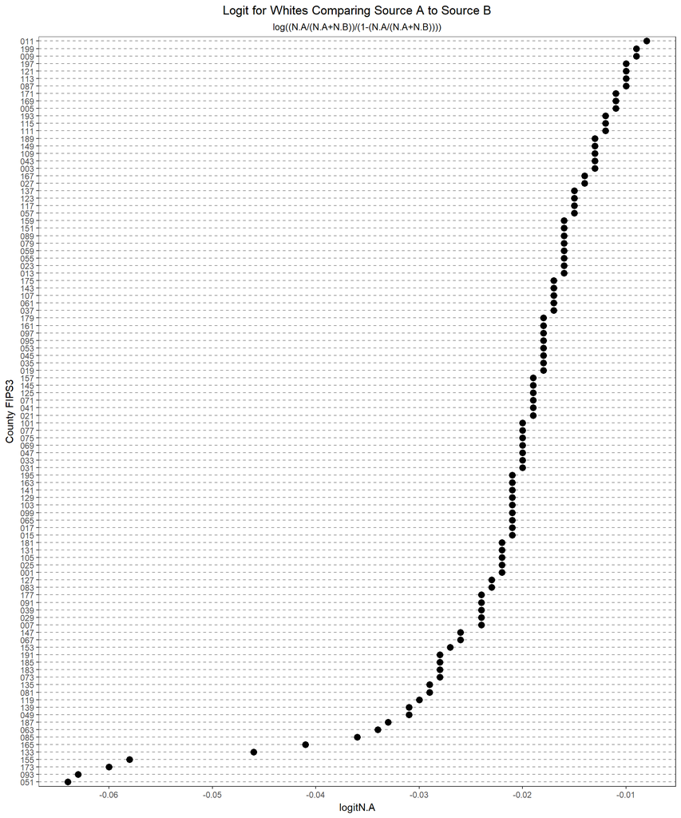

```r
df_cc_est2016_compare_N_source %>%
  dplyr::filter(
    race=="W"
  ) %>%
  ggplot(
    aes(y=reorder(FIPS3,logitN.A), x=logitN.A)
  ) +
  geom_point(size=3) +
  scale_x_continuous(breaks=seq(-.1,0,.01)) +
  labs(
    title="Logit for Whites Comparing Source A to Source B",
    subtitle="log((N.A/(N.A+N.B))/(1-(N.A/(N.A+N.B))))"
  ) +
  ylab("County FIPS3") +
  theme_bw() +
  theme(
    plot.title=element_text(hjust=0.5),
    plot.subtitle=element_text(hjust=0.5),
    panel.grid.major.x=element_blank(),
    panel.grid.minor.x=element_blank(),
    panel.grid.major.y=element_line(colour="grey60",linetype="dashed")
  )
```

Black

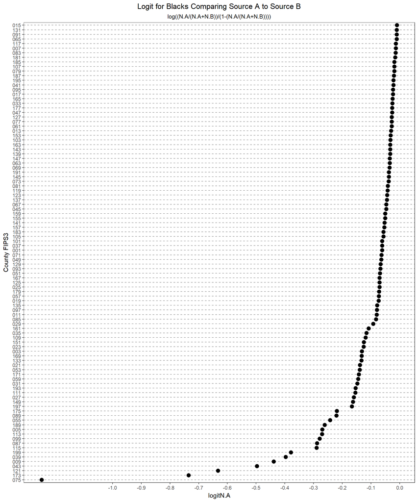

```r
df_cc_est2016_compare_N_source %>%
  dplyr::filter(
    race=="B"
  ) %>%
  ggplot(
    aes(y=reorder(FIPS3,logitN.A), x=logitN.A)
  ) +
  geom_point(size=3) +
  scale_x_continuous(breaks=seq(-1.0,0,.1)) +
  labs(
    title="Logit for Blacks Comparing Source A to Source B",
    subtitle="log((N.A/(N.A+N.B))/(1-(N.A/(N.A+N.B))))"
  ) +
  ylab("County FIPS3") +
  theme_bw() +
  theme(
    plot.title=element_text(hjust=0.5),
    plot.subtitle=element_text(hjust=0.5),
    panel.grid.major.x=element_blank(),
    panel.grid.minor.x=element_blank(),
    panel.grid.major.y=element_line(colour="grey60",linetype="dashed")
  )
```

## Considering the Hispanic Census Bureau Categories

```r
fn_df_cc_est2016_compare_Hisp <- function(){
  #
  # Use vectors to parse column headings.
  #
  #lst_colHead_HA_code <- list(
  #  "NHWA_"="W","HWA_"="W","NHBA_"="B","HBA_"="B","NHIA_"="I","HIA_"="I","NHAA_"="A","HAA_"="A"
  #)
  #lst_colHead_HA_code_names <- names(lst_colHead_HA_code)
  recode_colHeadHA <- "'NHWA_MALE'='W'; 'HWA_MALE'='W'; 'NHBA_MALE'='B'; 'HBA_MALE'='B'; 'NHIA_MALE'='I'; 'HIA_MALE'='I'; 'NHAA_MALE'='A'; 'HAA_MALE'='A'; 'NHWA_FEMALE'='W'; 'HWA_FEMALE'='W'; 'NHBA_FEMALE'='B'; 'HBA_FEMALE'='B'; 'NHIA_FEMALE'='I'; 'HIA_FEMALE'='I'; 'NHAA_FEMALE'='A'; 'HAA_FEMALE'='A'; else='O'"
  #
  df_ <-
  df_cc_est2016_tot %>%
  dplyr::select(
    FIPS3,
    NHWA_MALE,
    NHWA_FEMALE,
    NHBA_MALE,
    NHBA_FEMALE,
    NHIA_MALE,
    NHIA_FEMALE,
    NHAA_MALE,
    NHAA_FEMALE,
    NHNA_MALE,
    NHNA_FEMALE,
    NHTOM_MALE,
    NHTOM_FEMALE,
    HWA_MALE,
    HWA_FEMALE,
    HBA_MALE,
    HBA_FEMALE,
    HIA_MALE,
    HIA_FEMALE,
    HAA_MALE,
    HAA_FEMALE,
    HNA_MALE,
    HNA_FEMALE,
    HTOM_MALE,
    HTOM_FEMALE,
    pop
    ) %>%
  reshape2::melt(
    id.vars=c("pop","FIPS3")
  ) %>%
  dplyr::mutate(
    variable=as.character(variable)
  ) %>%
  dplyr::rowwise() %>%
  dplyr::mutate(
    sex=
      ifelse(
        stringr::str_detect(variable,"FEMALE"),
        "F",
        "M"
      ),
    race=
      car::recode(variable,recode_colHeadHA),
    hisp=
      ifelse(
        stringr::str_sub(variable,1,1)=="H",
        TRUE,
        FALSE
      ),
    source="A"
  ) %>%
  data.frame() %>%
  dplyr::select(
    pop,
    source,
    FIPS3,
    sex,
    race,
    hisp,
    value
  )
  #
  #lst_colHead_HB_code <- list(
  #  "NHWAC_"="W","HWAC_"="W","NHBAC_"="B","HBAC_"="B","NHIAC_"="I","HIAC_"="I","NHAAC_"="A","HAAC_"="A"
  #)
  #lst_colHead_HB_code_names <- names(lst_colHead_HB_code)
  recode_colHeadHB <- "'NHWAC_MALE'='W'; 'HWAC_MALE'='W'; 'NHBAC_MALE'='B'; 'HBAC_MALE'='B'; 'NHIAC_MALE'='I'; 'HIAC_MALE'='I'; 'NHAAC_MALE'='A'; 'HAAC_MALE'='A'; 'NHWAC_FEMALE'='W'; 'HWAC_FEMALE'='W'; 'NHBAC_FEMALE'='B'; 'HBAC_FEMALE'='B'; 'NHIAC_FEMALE'='I'; 'HIAC_FEMALE'='I'; 'NHAAC_FEMALE'='A'; 'HAAC_FEMALE'='A'; else='O'"
  #
  df_B <-
  df_cc_est2016_tot %>%
  dplyr::select(
    FIPS3,
    NHWAC_MALE,
    NHWAC_FEMALE,
    NHBAC_MALE,
    NHBAC_FEMALE,
    NHIAC_MALE,
    NHIAC_FEMALE,
    NHAAC_MALE,
    NHAAC_FEMALE,
    NHNAC_MALE,
    NHNAC_FEMALE,
    HWAC_MALE,
    HWAC_FEMALE,
    HBAC_MALE,
    HBAC_FEMALE,
    HIAC_MALE,
    HIAC_FEMALE,
    HAAC_MALE,
    HAAC_FEMALE,
    HNAC_MALE,
    HNAC_FEMALE,
    pop
    ) %>%
  reshape2::melt(
    id.vars=c("pop","FIPS3")
  ) %>%
  dplyr::mutate(
    variable=as.character(variable)
  ) %>%
  dplyr::rowwise() %>%
  dplyr::mutate(
    sex=
      ifelse(
        stringr::str_detect(variable,"FEMALE"),
        "F",
        "M"
      ),
    race=
      car::recode(variable,recode_colHeadHB),
    hisp=
      ifelse(
        stringr::str_sub(variable,1,1)=="H",
        TRUE,
        FALSE
      ),
    source="B"
  ) %>%
  data.frame() %>%
  dplyr::select(
    pop,
    source,
    FIPS3,
    sex,
    race,
    hisp,
    value
  )
  #
  # summarize
  #
  df_ <-
  rbind(
    df_,
    df_B
  ) %>%
  dplyr::group_by(
    pop,
    source,
    FIPS3,
    sex,
    race,
    hisp
  ) %>%
  dplyr::summarize(
    N=sum(value)
  ) %>%
  dplyr::ungroup()
  #
  return(df_)
}
```

```r
df_cc_est2016_compare_Hisp <- fn_df_cc_est2016_compare_Hisp()
str(df_cc_est2016_compare_Hisp)
```

```
## Classes 'tbl_df', 'tbl' and 'data.frame':    8000 obs. of  7 variables:
##  $ pop   : chr  "all" "all" "all" "all" ...
##  $ source: chr  "A" "A" "A" "A" ...
##  $ FIPS3 : chr  "001" "001" "001" "001" ...
##  $ sex   : chr  "F" "F" "F" "F" ...
##  $ race  : chr  "A" "A" "B" "B" ...
##  $ hisp  : logi  FALSE TRUE FALSE TRUE FALSE TRUE ...
##  $ N     : num  1128 74 15652 505 313 ...
```

Write as a csv file

```r
readr::write_csv(
  df_cc_est2016_compare_Hisp,
  paste0(output_dir,"df_cc_est2016_compare_Hisp.csv.gz")
)
```

## Problem in Counts

The data frames generated above share in a problem illustrated by these two tables:

Data not broken down into Hispanic:

```r
df_cc_est2016_compare %>%
  reshape2::dcast(pop+source~.,value.var = "N",sum)
```

```
##       pop source        .
## 1     all      A  9841590
## 2     all      B 10057990
## 3 voteage      A  7546946
## 4 voteage      B  7651900
```

Data broken down into Hispanic:

```r
df_cc_est2016_compare_Hisp %>%
  reshape2::dcast(pop+source~.,value.var = "N",sum)
```

```
##       pop source        .
## 1     all      A  9841590
## 2     all      B 10057990
## 3 voteage      A  7546897
## 4 voteage      B  7651873
```

There are mismatches between the source A and B data for the total counts. The Source A figure for total population agrees with that explicitly in the Census Bureau cc_est2016 file. Source B (the WAC… etc.) are the larger, so it appears that there may be a double counting somewhere in Source B.

The sum for Source A for data not broken down into Hispanic (the first of the dcasts) matches the sum from df_cc_est2016_tot.

```r
df_cc_est2016_tot %>% reshape2::dcast(pop~.,value.var = "TOT_POP",sum)
```

```
##       pop       .
## 1     all 9841590
## 2 voteage 7546959
```

This matches the sum from df_cc_est2016_alldata_37

```r
sum(df_cc_est2016_alldata_37 %>%
  dplyr::filter(YEAR==6 & AGEGRP==0) %>%
  dplyr::select(TOT_POP)
)
```

```
## [1] 9841590
```

Looking at totals:

```r
df_cc_est2016_alldata_37 %>%
  dplyr::filter(YEAR==6 & AGEGRP==0) %>%
  dplyr::select(
    TOT_POP,
    TOT_MALE,
    TOT_FEMALE,
    NH_MALE,
    NH_FEMALE,
    H_MALE,
    H_FEMALE
  ) %>%
  apply(2,sum)
```

```
##    TOT_POP   TOT_MALE TOT_FEMALE    NH_MALE  NH_FEMALE     H_MALE
##    9841590    4788063    5053527    4336055    4643812     452008
##   H_FEMALE
##     409715
```

and in more detail:

```r
count_cc_est2016_alldata_37 <-
df_cc_est2016_alldata_37 %>%
  dplyr::filter(YEAR==6 & AGEGRP==0) %>%
  dplyr::select(
    -SUMLEV,
    -STATE,
    -COUNTY,
    -STNAME,
    -CTYNAME,
    -YEAR,
    -AGEGRP
  ) %>%
  apply(2,sum)
#
count_cc_est2016_alldata_37
```

```
##      TOT_POP     TOT_MALE   TOT_FEMALE      WA_MALE    WA_FEMALE
##      9841590      4788063      5053527      3467567      3580332
##      BA_MALE    BA_FEMALE      IA_MALE    IA_FEMALE      AA_MALE
##      1019068      1156123        76145        77254       122897
##    AA_FEMALE      NA_MALE    NA_FEMALE     TOM_MALE   TOM_FEMALE
##       132519         5984         5613        96402       101686
##     WAC_MALE   WAC_FEMALE     BAC_MALE   BAC_FEMALE     IAC_MALE
##      3551464      3667568      1074661      1216250       109665
##   IAC_FEMALE     AAC_MALE   AAC_FEMALE     NAC_MALE   NAC_FEMALE
##       114009       146869       157373        10148         9983
##      NH_MALE    NH_FEMALE    NHWA_MALE  NHWA_FEMALE    NHBA_MALE
##      4336055      4643812      3095907      3246740       983233
##  NHBA_FEMALE    NHIA_MALE  NHIA_FEMALE    NHAA_MALE  NHAA_FEMALE
##      1120690        54247        58203       118181       128159
##    NHNA_MALE  NHNA_FEMALE   NHTOM_MALE NHTOM_FEMALE   NHWAC_MALE
##         3055         3086        81432        86934      3166787
## NHWAC_FEMALE   NHBAC_MALE NHBAC_FEMALE   NHIAC_MALE NHIAC_FEMALE
##      3321279      1030442      1172101        80881        88346
##   NHAAC_MALE NHAAC_FEMALE   NHNAC_MALE NHNAC_FEMALE       H_MALE
##       139254       150166         6316         6617       452008
##     H_FEMALE     HWA_MALE   HWA_FEMALE     HBA_MALE   HBA_FEMALE
##       409715       371660       333592        35835        35433
##     HIA_MALE   HIA_FEMALE     HAA_MALE   HAA_FEMALE     HNA_MALE
##        21898        19051         4716         4360         2929
##   HNA_FEMALE    HTOM_MALE  HTOM_FEMALE    HWAC_MALE  HWAC_FEMALE
##         2527        14970        14752       384677       346289
##    HBAC_MALE  HBAC_FEMALE    HIAC_MALE  HIAC_FEMALE    HAAC_MALE
##        44219        44149        28784        25663         7615
##  HAAC_FEMALE    HNAC_MALE  HNAC_FEMALE
##         7207         3832         3366
```

```r
#
df_count_cc_est2016_alldata_37 <-
  data.frame(name=names(count_cc_est2016_alldata_37),N=count_cc_est2016_alldata_37)
```

The problem with these talleys seems to be that the “HWA_…” (including HTOM_) sum equals H_MALE+H_FEMALE,  
while the “HWAC_…” series sum is larger. Whatever the source of this, for our purposes the Hispanic counts  
will be represented by the “HWA_…” series.

## Hispanic-based County Counts

NOTE that df_cc_est2016_compare_Hisp must be filtered to use source “A” only.

The NCSBE race categories are A, B, I, M, O, U, W.  
The Census Bureau race categories are A, B, I, O, W.  
The view of NCSBE v_df_merge_county_sex_race_OMU_20161108() race categories are A, B, I, O, W.

These data frame representations of the data WITHOUT ETHNICITY:

```r
df_merge_county_sex_race_20161108 %>% reshape2::dcast(pop+sex+race~.,value.var = "N",sum)
```

```
##        pop sex race       .
## 1      all   F    A  132519
## 2      all   F    B 1156123
## 3      all   F    I   77254
## 4      all   F    M  101686
## 5      all   F    O    5613
## 6      all   F    W 3580332
## 7      all   M    A  122897
## 8      all   M    B 1019068
## 9      all   M    I   76145
## 10     all   M    M   96402
## 11     all   M    O    5984
## 12     all   M    W 3467567
## 13   regis   F    A   43404
## 14   regis   F    B  867305
```

[output cut: 52 more lines]

```r
df_cc_est2016_compare_Hisp %>% dplyr::filter(source=="A") %>% reshape2::dcast(pop+sex+race~.,value.var = "N",sum)
```

```
##        pop sex race       .
## 1      all   F    A  132519
## 2      all   F    B 1156123
## 3      all   F    I   77254
## 4      all   F    O  107299
## 5      all   F    W 3580332
## 6      all   M    A  122897
## 7      all   M    B 1019068
## 8      all   M    I   76145
## 9      all   M    O  102386
## 10     all   M    W 3467567
## 11 voteage   F    A   98900
## 12 voteage   F    B  876165
## 13 voteage   F    I   54804
## 14 voteage   F    O   54444
## 15 voteage   F    W 2845318
## 16 voteage   M    A   89226
## 17 voteage   M    B  732296
## 18 voteage   M    I   53237
## 19 voteage   M    O   48264
## 20 voteage   M    W 2694243
```

```r
v_df_merge_county_sex_race_OMU_20161108() %>% reshape2::dcast(pop+sex+race~.,value.var = "N",sum)
```

```
##        pop sex race       .
## 1      all   F    A  132519
## 2      all   F    B 1156123
## 3      all   F    I   77254
## 4      all   F    O  107299
## 5      all   F    W 3580332
## 6      all   M    A  122897
## 7      all   M    B 1019068
## 8      all   M    I   76145
## 9      all   M    O  102386
## 10     all   M    W 3467567
## 11   regis   F    A   43404
## 12   regis   F    B  867305
## 13   regis   F    I   31547
## 14   regis   F    O  181129
```

[output cut: 36 more lines]

In a more compact display, not including sex WITHOUT ETHNICITY:

```r
df_merge_county_sex_race_20161108 %>% reshape2::dcast(pop~race,value.var = "N",sum)
```

```
##       pop      A       B      I      M      O      U       W
## 1     all 255416 2175191 153399 198088  11597      0 7047899
## 2   regis  81210 1536677  56661  47560 166529 233220 4802439
## 3 voteage 188136 1608467 108052  95270   7461      0 5539560
## 4   voted  49653  940914  27836  24756  87990 138317 3307070
```

```r
df_cc_est2016_compare_Hisp %>% dplyr::filter(source=="A") %>% reshape2::dcast(pop~race,value.var = "N",sum)
```

```
##       pop      A       B      I      O       W
## 1     all 255416 2175191 153399 209685 7047899
## 2 voteage 188126 1608461 108041 102708 5539561
```

```r
v_df_merge_county_sex_race_OMU_20161108() %>% reshape2::dcast(pop~race,value.var = "N",sum)
```

```
##       pop      A       B      I      O       W
## 1     all 255416 2175191 153399 209685 7047899
## 2   regis  81210 1536677  56661 447309 4802439
## 3 voteage 188136 1608467 108052 102731 5539560
## 4   voted  49653  940914  27836 251063 3307070
```

### The Problem With NCSBE Ethnicity

Reporting of ethnic_code in df_nc_voted:

```r
df_nc_voted %>% reshape2::dcast(ethnic_code~.)
```

```
##   ethnic_code       .
## 1          HL   96185
## 2          NL 3784638
## 3          UN  886856
```

The non-responses outnumber the HL responses by a factor of nine. It does not appear reasonable to carry out any analysis of ethnicity of voters.

## Finish

Do not resave df_nc_voted

```r
rm(df_nc_voted)
ls()
```

```
##  [1] "B_df_cc_est2016_compare_N_quintile"
##  [2] "Census_NCACC_files_in_"
##  [3] "count_cc_est2016_alldata_37"
##  [4] "data_dir"
##  [5] "df_cc_est2016_alldata_37"
##  [6] "df_cc_est2016_compare"
##  [7] "df_cc_est2016_compare_Hisp"
##  [8] "df_cc_est2016_compare_N"
##  [9] "df_cc_est2016_compare_N_source"
## [10] "df_cc_est2016_county_race_dcast"
## [11] "df_cc_est2016_county_sex_race_long_recoded"
## [12] "df_cc_est2016_tot"
## [13] "df_cc_est2016_tot_only"
## [14] "df_cc_est2016_tot_subset"
## [15] "df_count_cc_est2016_alldata_37"
```

[output cut: 34 more lines]

```r
save.image("AWR_Census_NCACC_cat.RData")
```